# Beta diversity and ordination

Mateu Menendez Serra (mateu.menendez@sund.ku.dk)

2026-05-27

Beta diversity and ordination

# Overview

In this session, we will continue working with the same phyloseq object created in the previous practical and use phyloseq’s built-in functions to explore patterns of **beta diversity** across samples.

Beta diversity describes the differences in community composition **between samples**. Unlike alpha diversity, which focuses on diversity within individual samples, beta diversity asks whether some microbial communities are compositionally more similar to each other than to the rest.

In this practical, we will focus on two closely related goals:

- estimating beta-diversity distances between samples,
- and visualising those distances using ordination methods.

Throughout the session, we will move from simple distance estimation to ordination, visual interpretation, and formal statistical testing.

# 1. Load the phyloseq object

This practical assumes that you already created a phyloseq object in the previous session and saved it as an `.rds` file. We will load that object here so that everyone starts from the same point.

```r
library(phyloseq)
library(tidyverse)
library(tibble)
library(vegan)
```

```r
ps <- readRDS(file.path("../data", "phyloseq_augmented_v2.rds"))

ps
```

```
## phyloseq-class experiment-level object
## otu_table()   OTU Table:         [ 173 taxa and 30 samples ]
## sample_data() Sample Data:       [ 30 samples by 5 sample variables ]
## tax_table()   Taxonomy Table:    [ 173 taxa by 7 taxonomic ranks ]
```

# 2. Beta-diversity estimation

Before calculating beta diversity, it is important to remember that distances between samples depend strongly on how abundance values are represented.

For example:

- some distance metrics are usually applied to **relative abundances**,
- while others are often based on **presence/absence** data,
- and some metrics are more sensitive to abundant taxa than others.

For this reason, we will first create alternative versions of the phyloseq object that contain transformed abundance tables.

## Preparing transformed phyloseq objects

One common first step is to convert each sample to relative abundance so that the total abundance of every sample is scaled to 1.

```r
ps_rel <- transform_sample_counts(
  ps,
  function(x) x / sum(x)
)

sample_sums(ps_rel)
```

```
## ERR2641635 ERR2641677 ERR2641733 SRR8692206 SRR8692207 SRR8692213  SRR059458
##          1          1          1          1          1          1          1
##  SRR059459  SRR513791 SIM2291543 SIM5894288 SIM8279698 SIM2306496 SIM8896464
##          1          1          1          1          1          1          1
## SIM5814710 SIM8854893 SIM9240152 SIM1790957 SIM4881755 SIM4173338 SIM7930175
##          1          1          1          1          1          1          1
## SIM6193423 SIM2131093 SIM3592908 SIM4014702 SIM9347053 SIM7937391 SIM1208744
##          1          1          1          1          1          1          1
## SIM2733238 SIM4801093
##          1          1
```

In some cases, we may want to focus only on whether a taxon is detected or not, without considering its abundance.

```r
ps_pa <- transform_sample_counts(
  ps,
  function(x){ifelse(x > 0, 1, 0)}
)

sample_sums(ps_pa)
```

```
## ERR2641635 ERR2641677 ERR2641733 SRR8692206 SRR8692207 SRR8692213  SRR059458
##         77         96        108         27         33         27         31
##  SRR059459  SRR513791 SIM2291543 SIM5894288 SIM8279698 SIM2306496 SIM8896464
##         31          2        111        114         90        116        116
## SIM5814710 SIM8854893 SIM9240152 SIM1790957 SIM4881755 SIM4173338 SIM7930175
##         81        103        116        106        120        105         93
## SIM6193423 SIM2131093 SIM3592908 SIM4014702 SIM9347053 SIM7937391 SIM1208744
##        114        121        139        140        120         84        134
## SIM2733238 SIM4801093
##        140        139
```

## Calculating beta-diversity distances

phyloseq provides the function `distance()` to calculate pairwise distances between samples directly from a phyloseq object.

The result is a distance matrix in which:

- small values indicate that two samples are compositionally similar,
- and large values indicate that they are more different.

In this session, we will focus on two commonly used beta-diversity metrics:

- **Bray-Curtis distance**, which is based on abundance differences between samples.
- **Jaccard distance**, which focuses on shared versus unshared taxa.

Bray-Curtis distance is one of the most widely used measures in microbial community analysis. It is sensitive to differences in taxon abundances and is therefore commonly applied to relative-abundance data.

```r
bray_dist <- distance(
  ps_rel,
  method = "bray"
)

bray_dist
```

```
##             ERR2641635  ERR2641677  ERR2641733  SRR8692206  SRR8692207
## ERR2641677 0.741167606
## ERR2641733 0.672078774 0.685474460
## SRR8692206 0.942725785 0.935476920 0.964233024
## SRR8692207 0.943448594 0.969327965 0.975915979 0.944968323
## SRR8692213 0.946397970 0.945564379 0.955808649 0.963959285 0.815458353
## SRR059458  1.000000000 1.000000000 1.000000000 0.999832829 1.000000000
## SRR059459  1.000000000 1.000000000 1.000000000 0.999832829 1.000000000
## SRR513791  1.000000000 0.998969803 1.000000000 0.994953962 0.994953962
## SIM2291543 0.714015950 0.477389831 0.712504991 0.932041516 0.911975295
## SIM5894288 0.720898592 0.812633028 0.462840343 0.973141089 0.868720561
## SIM8279698 0.401364495 0.813249510 0.806703721 0.895161791 0.968351243
## SIM2306496 0.753210142 0.788664406 0.470308956 0.975949912 0.857993258
## SIM8896464 0.785744512 0.779073109 0.440912629 0.958244790 0.954480200
## SIM5814710 0.347866702 0.822791342 0.777146592 0.977998974 0.910916278
## SIM8854893 0.851855187 0.437526123 0.778326753 0.948824979 0.878425651
## SIM9240152 0.923841394 0.896518801 0.910977838 0.938066925 0.820458959
## SIM1790957 0.932898211 0.909294485 0.943833725 0.938161326 0.813681716
## SIM4881755 0.964084530 0.944903372 0.933175240 0.994993383 0.223522810
## SIM4173338 0.904372974 0.849128362 0.922205876 0.967236359 0.820741239
## SIM7930175 0.827721804 0.904924956 0.905114951 0.287964131 0.892262615
## SIM6193423 0.952978428 0.899576769 0.933800468 0.978949062 0.829264672
## SIM2131093 0.944928305 0.959545468 0.958694232 0.918653352 0.139561582
## SIM3592908 0.960431300 0.952893814 0.970089707 0.957243741 0.992683369
## SIM4014702 0.970758936 0.967204865 0.974485071 0.944394224 0.995616630
## SIM9347053 0.956753277 0.979700826 0.966016409 0.999907647 0.942865173
## SIM7937391 0.938938861 0.977548746 0.965832233 0.922605346 0.935853941
## SIM1208744 0.965667002 0.933245869 0.960117011 0.986765893 0.982629506
## SIM2733238 0.992532706 0.988144895 0.990160198 0.917287724 0.977480867
## SIM4801093 0.985446134 0.979062608 0.985127043 0.999752204 0.917385284
##             SRR8692213   SRR059458   SRR059459   SRR513791  SIM2291543
## ERR2641677
## ERR2641733
## SRR8692206
## SRR8692207
## SRR8692213
## SRR059458  1.000000000
## SRR059459  1.000000000 0.003680091
## SRR513791  1.000000000 1.000000000 1.000000000
## SIM2291543 0.963714497 1.000000000 1.000000000 0.994953962
```

[output cut: 125 more lines]

```
## SIM8854893
## SIM9240152
## SIM1790957
## SIM4881755
## SIM4173338
## SIM7930175
## SIM6193423
## SIM2131093
## SIM3592908
## SIM4014702
## SIM9347053
## SIM7937391 0.998538630
## SIM1208744 0.446032131 0.985448618
## SIM2733238 0.458371112 0.988273735 0.328206566
## SIM4801093 0.417282777 0.994220747 0.499982965 0.437671314
```

Jaccard distance is often applied to presence/absence data and focuses on whether the same taxa are present in two samples, regardless of their abundances.

```r
jaccard_dist <- distance(
  ps_pa,
  method = "jaccard"
)

jaccard_dist
```

```
##             ERR2641635  ERR2641677  ERR2641733  SRR8692206  SRR8692207
## ERR2641677 0.441441441
## ERR2641733 0.445378151 0.300000000
## SRR8692206 0.869565217 0.911504425 0.875000000
## SRR8692207 0.791208791 0.848214286 0.834710744 0.604651163
## SRR8692213 0.746987952 0.839622642 0.836206897 0.540540541 0.421052632
## SRR059458  1.000000000 1.000000000 1.000000000 0.964285714 1.000000000
## SRR059459  1.000000000 1.000000000 1.000000000 0.964285714 1.000000000
## SRR513791  1.000000000 0.989690722 1.000000000 0.964285714 0.970588235
## SIM2291543 0.459016393 0.135135135 0.302325581 0.850000000 0.714285714
## SIM5894288 0.434426230 0.292682927 0.052631579 0.853658537 0.814516129
## SIM8279698 0.144444444 0.450000000 0.453125000 0.741935484 0.744897959
## SIM2306496 0.443548387 0.304000000 0.068965517 0.837398374 0.808000000
## SIM8896464 0.443548387 0.304000000 0.068965517 0.837398374 0.808000000
## SIM5814710 0.049382716 0.447368421 0.450819672 0.838709677 0.774193548
## SIM8854893 0.421052632 0.067961165 0.284552846 0.849557522 0.807017544
## SIM9240152 0.443548387 0.304000000 0.068965517 0.837398374 0.808000000
## SIM1790957 0.422413793 0.094339623 0.288000000 0.823008850 0.791304348
## SIM4881755 0.472868217 0.338461538 0.115702479 0.842519685 0.725000000
## SIM4173338 0.431034483 0.103773585 0.296000000 0.821428571 0.789473684
## SIM7930175 0.172043011 0.475806452 0.465648855 0.709677419 0.752475248
## SIM6193423 0.434426230 0.320000000 0.086206897 0.834710744 0.804878049
## SIM2131093 0.476923077 0.330769231 0.107438017 0.843750000 0.727272727
## SIM3592908 0.550335570 0.321428571 0.426751592 0.822695035 0.829931973
## SIM4014702 0.572368421 0.338028169 0.450000000 0.807142857 0.823129252
## SIM9347053 0.358333333 0.578947368 0.575000000 0.860465116 0.745901639
## SIM7937391 0.083333333 0.448275862 0.464000000 0.831578947 0.768421053
## SIM1208744 0.544827586 0.296296296 0.428571429 0.858156028 0.840277778
## SIM2733238 0.553333333 0.326241135 0.430379747 0.815602837 0.823129252
## SIM4801093 0.578947368 0.345070423 0.465838509 0.870748299 0.780141844
##             SRR8692213   SRR059458   SRR059459   SRR513791  SIM2291543
## ERR2641677
## ERR2641733
## SRR8692206
## SRR8692207
## SRR8692213
## SRR059458  1.000000000
## SRR059459  1.000000000 0.000000000
## SRR513791  1.000000000 1.000000000 1.000000000
## SIM2291543 0.789473684 1.000000000 1.000000000 0.991071429
```

[output cut: 125 more lines]

```
## SIM8854893
## SIM9240152
## SIM1790957
## SIM4881755
## SIM4173338
## SIM7930175
## SIM6193423
## SIM2131093
## SIM3592908
## SIM4014702
## SIM9347053
## SIM7937391 0.354838710
## SIM1208744 0.350649351 0.506849315
## SIM2733238 0.343949045 0.535947712 0.070422535
## SIM4801093 0.296052632 0.561290323 0.117241379 0.114864865
```

These two distances capture different aspects of community variation and should therefore not be expected to produce identical results.

# 3. Ordination

Distance matrices are difficult to interpret directly because they contain pairwise comparisons between all samples.

Ordination methods help us summarise these relationships in a small number of dimensions so that patterns can be visualised more easily.

phyloseq provides the function `ordinate()` to compute ordinations and `plot_ordination()` to visualise them.

In this session, we will focus on two commonly used ordination methods:

- **PCoA** (Principal Coordinates Analysis).
- **NMDS** (Non-metric Multidimensional Scaling).

## PCoA based on Bray-Curtis distance

PCoA is a useful first ordination method because it attempts to represent the pairwise sample distances in a lower-dimensional Euclidean space.

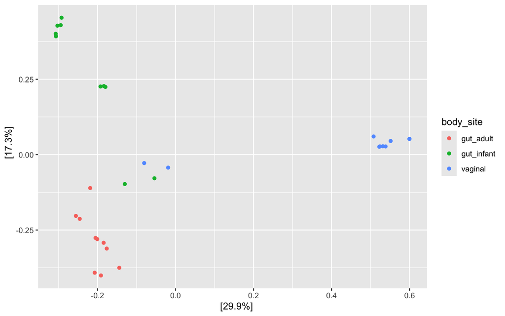

```r
ord_bray <- ordinate(
  ps_rel,
  method = "PCoA",
  distance = bray_dist
)

plot_ordination(
  ps_rel,
  ord_bray,
  type = "samples",
  color = "body_site"
)
```

The resulting plot can be used to explore whether samples from the same body site tend to cluster together and whether different body-site categories appear compositionally distinct.

## Visualising the explained variation

For PCoA, it is often useful to inspect how much of the variation is represented by the first few axes.

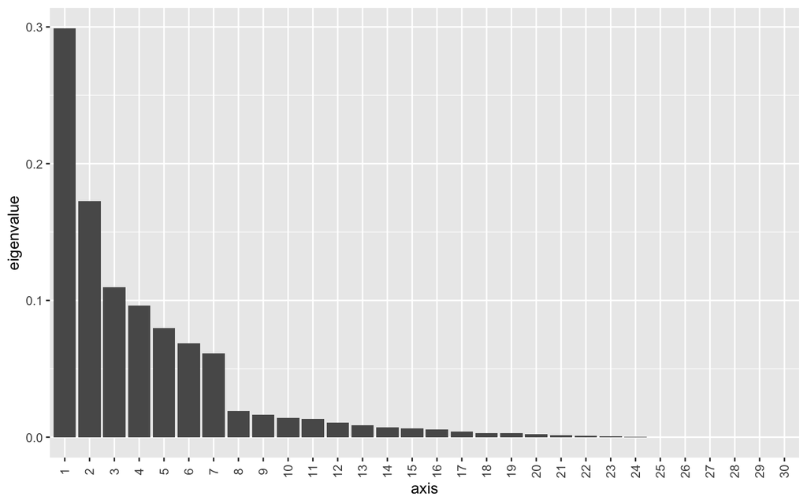

```r
plot_scree(ord_bray)
```

## Extracting ordination coordinates

The built-in plot is useful for quick inspection, but it is often convenient to extract the ordination coordinates as a standard data frame so that we can customise the visualisation further with ggplot2.

```r
ord_bray_df <- plot_ordination(
  ps_rel,
  ord_bray,
  type = "samples",
  justDF = TRUE
)

head(ord_bray_df)
```

```
##                 Axis.1      Axis.2  body_site simulated
## ERR2641635 -0.19134011 -0.40070495  gut_adult     FALSE
## ERR2641677 -0.18442560 -0.29232214  gut_adult     FALSE
## ERR2641733 -0.20742454 -0.39155836  gut_adult     FALSE
## SRR8692206 -0.05421179 -0.07841269 gut_infant     FALSE
## SRR8692207 -0.17987490  0.22458399 gut_infant     FALSE
## SRR8692213 -0.29229800  0.45417384 gut_infant     FALSE
##            simulation_source_sample simulation_source_group simulation_method
## ERR2641635                     <NA>                    <NA>              <NA>
## ERR2641677                     <NA>                    <NA>              <NA>
## ERR2641733                     <NA>                    <NA>              <NA>
## SRR8692206                     <NA>                    <NA>              <NA>
## SRR8692207                     <NA>                    <NA>              <NA>
## SRR8692213                     <NA>                    <NA>              <NA>
```

Once the coordinates and metadata are into a single table, we can create a more flexible plot:

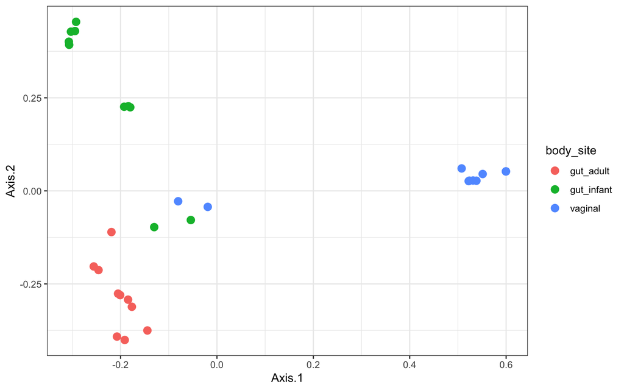

```r
ggplot(ord_bray_df, aes(x = Axis.1, y = Axis.2, color = body_site)) +
  geom_point(size = 3) +
  theme_bw()
```

## NMDS based on Bray-Curtis distance

NMDS is another commonly used ordination method in ecology and microbiome analysis. Unlike PCoA, it focuses on preserving the rank order of distances rather than the distances themselves.

```r
ord_nmds <- ordinate(
  ps_rel,
  method = "NMDS",
  distance = "bray"
)
```

```
## *** Best solution repeated 2 times
```

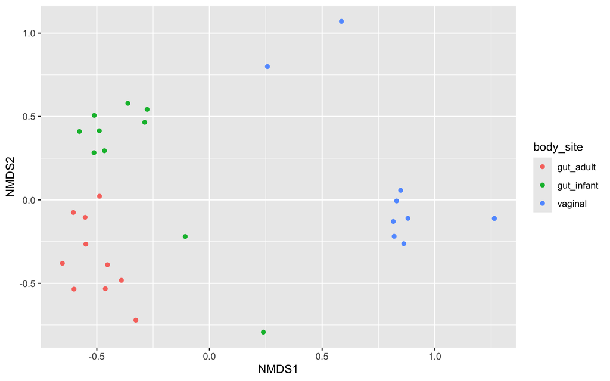

```r
plot_ordination(
  ps_rel,
  ord_nmds,
  type = "samples",
  color = "body_site"
)
```

NMDS is often particularly useful when ecological relationships are non-linear, although the results can vary slightly between runs because the algorithm uses an iterative optimisation procedure.

## Exercise: Comparing Bray-Curtis and Jaccard

Now let us repeat the same ordination workflow using **Jaccard distance** instead of Bray-Curtis distance.

Take a few minutes to create and inspect an equivalent ordination plot for Jaccard distance, and think about how the patterns compare with the Bray-Curtis ordination.

Questions to consider:

- Do the same sample groups cluster together under both distance metrics?
- Are the differences between groups stronger or weaker when only presence/absence information is used?
- What does this suggest about the relative importance of taxon abundance versus taxon membership in your dataset?

```r
# Calculate a PCoA ordination from the Jaccard distance matrix
```

# 4. Statistical testing

Ordination plots are very useful for quick exploratory visualisations, but in many analyses we also want to perform formal statistical testing to evaluate whether community composition differs significantly between groups of samples.

For this, we will use PERMANOVA (Permutational Multivariate Analysis of Variance), implemented in the `vegan` package through the function `adonis2()`.

## Combining beta-diversity distances with sample metadata

Before running the test, it is convenient to extract the sample metadata stored in the phyloseq object.

```r
sample_df <- sample_data(ps_rel) %>%
  data.frame()

head(sample_df)
```

```
##             body_site simulated simulation_source_sample
## ERR2641635  gut_adult     FALSE                     <NA>
## ERR2641677  gut_adult     FALSE                     <NA>
## ERR2641733  gut_adult     FALSE                     <NA>
## SRR8692206 gut_infant     FALSE                     <NA>
## SRR8692207 gut_infant     FALSE                     <NA>
## SRR8692213 gut_infant     FALSE                     <NA>
##            simulation_source_group simulation_method
## ERR2641635                    <NA>              <NA>
## ERR2641677                    <NA>              <NA>
## ERR2641733                    <NA>              <NA>
## SRR8692206                    <NA>              <NA>
## SRR8692207                    <NA>              <NA>
## SRR8692213                    <NA>              <NA>
```

Now that we have both a distance matrix and the associated sample metadata, we can formally test whether community composition differs between groups of samples.

A common first approach is to compare community composition across environments or sample types.

For example, we may want to ask:

*Do microbial communities from different body sites show significantly different overall composition?*

## Testing Bray-Curtis distances across body sites

```r
adonis_bray <- adonis2(
  bray_dist ~ body_site,
  data = sample_df,
  permutations = 999
)

adonis_bray
```

```
## Permutation test for adonis under reduced model
## Permutation: free
## Number of permutations: 999
##
## adonis2(formula = bray_dist ~ body_site, data = sample_df, permutations = 999)
##          Df SumOfSqs      R2      F Pr(>F)
## Model     2   4.6545 0.40898 9.3418  0.001 ***
## Residual 27   6.7263 0.59102
## Total    29  11.3807 1.00000
## ---
## Signif. codes:  0 '***' 0.001 '**' 0.01 '*' 0.05 '.' 0.1 ' ' 1
```

The output includes a p-value that helps us evaluate whether microbial communities differ in overall composition across the groups being compared.

A small p-value, commonly below `0.05`, suggests evidence against the null hypothesis that all groups have similar multivariate composition, whereas a larger p-value indicates that the observed differences could plausibly arise by chance.

## Checking homogeneity of dispersion

One important limitation of PERMANOVA is that significant results can sometimes reflect not only differences in group centroids, but also differences in within-group dispersion.

We can explore this by using `betadisper()`.

```r
dispersion_bray <- betadisper(
  bray_dist,
  sample_df$body_site
)

anova(dispersion_bray)
```

```
## Analysis of Variance Table
##
## Response: Distances
##           Df  Sum Sq  Mean Sq F value Pr(>F)
## Groups     2 0.07963 0.039816  0.6675 0.5213
## Residuals 27 1.61056 0.059650
```

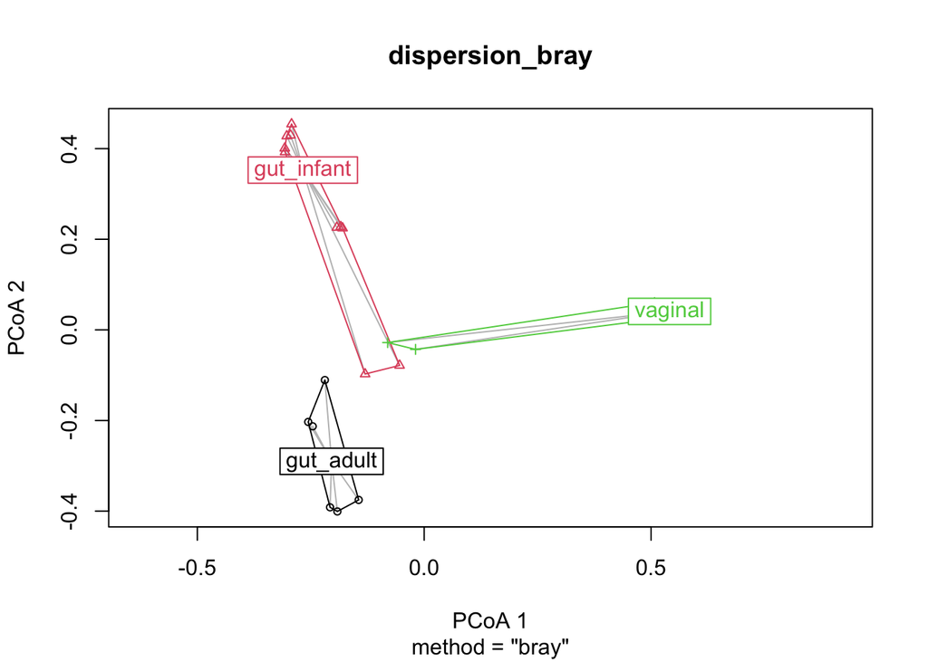

```r
plot(dispersion_bray)
```

If dispersion differs strongly between groups, then a significant PERMANOVA result should be interpreted with caution.

## Visualising ordination with group structure

Statistical tests are much easier to interpret when combined with visualisations.

A common approach is to display the ordination plot together with group labels and inspect whether the observed separation is visually consistent with the statistical result.

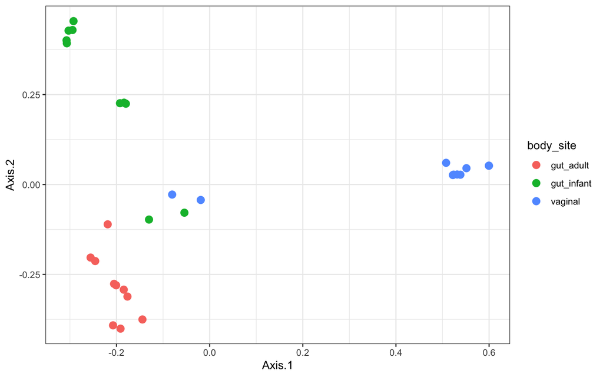

```r
ggplot(ord_bray_df, aes(x = Axis.1, y = Axis.2, color = body_site)) +
  geom_point(size = 3) +
  theme_bw()
```

## Exercise: Testing Jaccard distances

Repeat the same analysis using Jaccard distance instead of Bray-Curtis distance.

Tasks:

1. Perform a PERMANOVA test for Jaccard distance across body sites.
2. Compare the results obtained for Bray-Curtis and Jaccard distance.
3. Think about why abundance-based and presence/absence-based metrics might lead to different biological interpretations.

Questions to consider:

- Do both metrics lead to the same biological interpretation?
- Which metric shows stronger differences between body sites?
- Why might abundance-based and presence/absence-based distances behave differently?

## Exercise: Comparing a subset of samples

In some cases, it may be useful to restrict the analysis to a subset of environments and ask whether the same broad pattern still holds.

For example, you may want to compare only the `gut_adult` and `gut_infant` groups.

```r
ps_rel_gut <- subset_samples(
  ps_rel,
  body_site %in% c("gut_adult", "gut_infant")
)

bray_dist_gut <- distance(
  ps_rel_gut,
  method = "bray"
)

sample_df_gut <- sample_data(ps_rel_gut) %>%
  data.frame()

adonis2(
  bray_dist_gut ~ body_site,
  data = sample_df_gut,
  permutations = 999
)
```

```
## Permutation test for adonis under reduced model
## Permutation: free
## Number of permutations: 999
##
## adonis2(formula = bray_dist_gut ~ body_site, data = sample_df_gut, permutations = 999)
##          Df SumOfSqs      R2      F Pr(>F)
## Model     1   1.7189 0.26442 6.4706  0.001 ***
## Residual 18   4.7818 0.73558
## Total    19   6.5007 1.00000
## ---
## Signif. codes:  0 '***' 0.001 '**' 0.01 '*' 0.05 '.' 0.1 ' ' 1
```

Questions to consider:

- Does the separation become clearer when focusing on fewer groups?
- Do the statistical results change when fewer environments are compared?